# Activity 8 _ SELF-ORGANIZING MAPS

Fakhraddin Jaf

April 9, 2017

### Finding the optimal threshold for a foreground detection system

#### Loading required libraries:

```r
library("kohonen")
library("tiff")
library("plotly")
options(error=traceback)
```

#### A) Loading the image and training a self-organizing map:

At this step we Load the f0001000.tif image (using **readTIFF** function of the **tiff** package) and then by a sequenced pattern of its pixels, we train a self-organizing map with 16x16 neurons (using **som** function of the **kohonen** package). Finally, we plot a mosaic of 16x16 squares where each square is painted in the color of the associated neuron prototype.  
The **som** function implements the standard form of self-organizing maps:

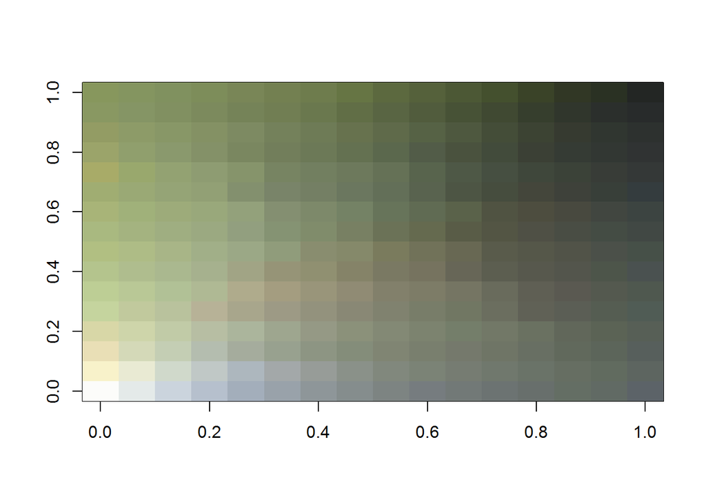

```r
reference_image = readTIFF("f0001000.tif") #view image
image_size <- dim(reference_image)
patterns <- reference_image
dim(patterns) <- c(image_size[1]*image_size[2],image_size[3])
colnames(patterns) <- c("R", "G", "B")

# Train the SOM
m <- som(patterns[seq(1,image_size[1]*image_size[2],10),], grid=somgrid(16,16,"hexagonal"))

# Show the SOM as colors:
color_vec <- c(unlist(m$codes))
color_mat <- cbind(color_vec[1:256],color_vec[257:512], color_vec[513:768])
color_palette <- rgb(color_mat)
image(matrix(1:256,nrow=16,ncol=16),col=color_palette)
```

#### B) Computing the quantization error:

At this step we Load the f0001664.tif image (again using **readTIFF** function of the **tiff** package) and then we use the **map** function from **kohonen** package to map the matrix of its pixel patterns onto the trained SOM (the SOM which we trained at previous step), and then using the **distances** component of the **map** function, we obtain a matrix of quantization errors. Finally we plot the quantization errors:

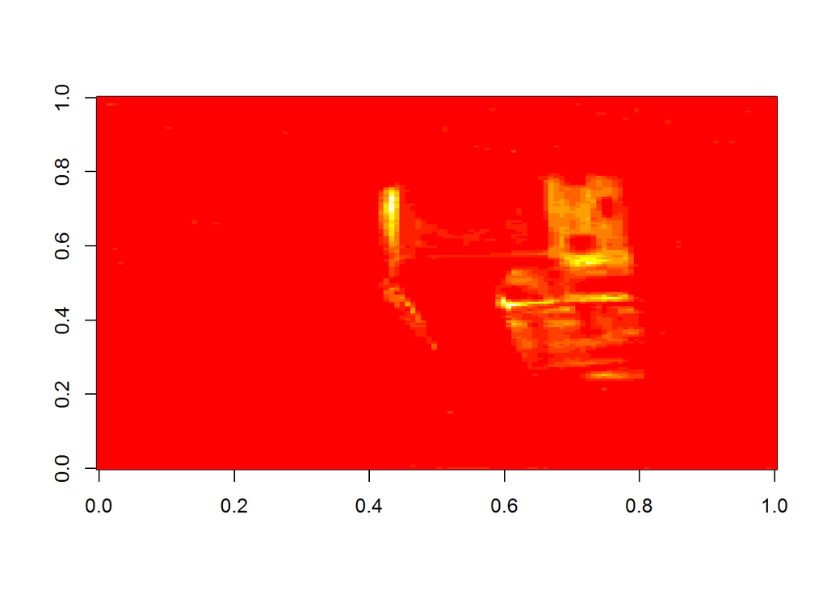

```r
incoming_image = readTIFF("f0001664.tif") #view image
patterns_test <- incoming_image
dim(patterns_test) <- c(image_size[1]*image_size[2],image_size[3])

# Get the quantization errors for all the pixels
quantization_errors <- kohonen::map(m,patterns_test)$distances
dim(quantization_errors) <- c(image_size[1],image_size[2])
image(quantization_errors)
```

#### C) Building ground truth mask:

At this step we use the ground truth mask for the foreground detection system. To do so we load the f0001664gt.tif image, and then obtain a binary bidimensional matrix with **true** values for pixel tones higher than **0.5**, and **false** values for pixel tones lower than **0.5**.

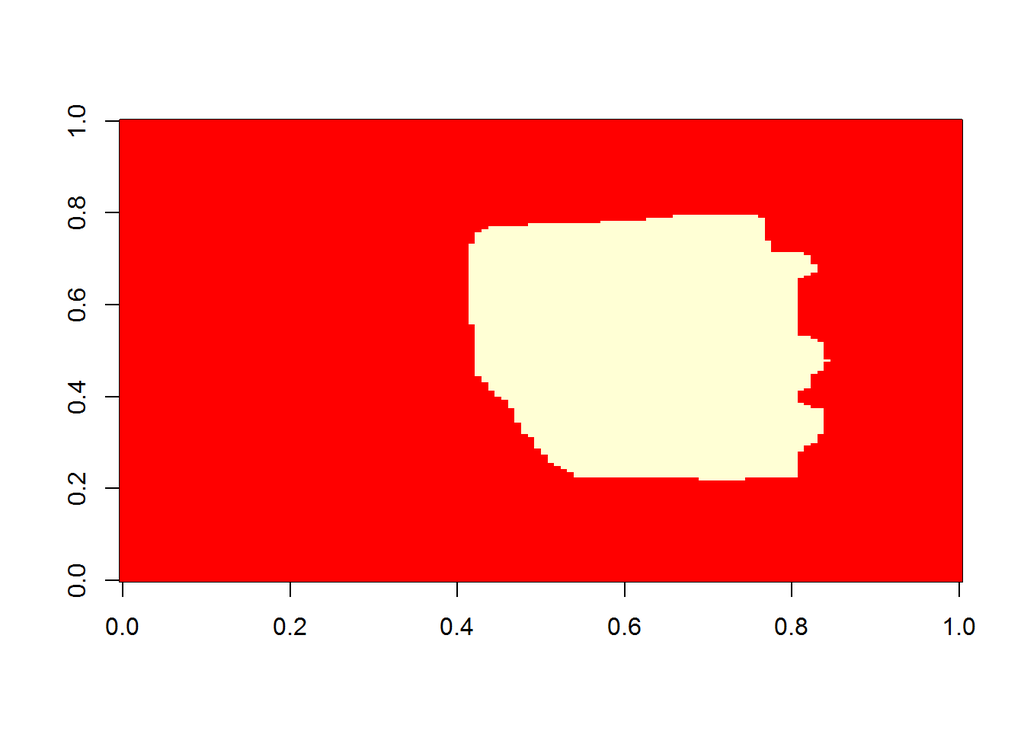

```r
# we load the ground truth image:
ground_truth_image <- readTIFF("f0001664gt.tif") #view image
gti_size <- dim(ground_truth_image)

patterns_gti <- ground_truth_image
dim(patterns_gti) <- c(gti_size[1]*gti_size[2],gti_size[3])
colnames(patterns_gti) <- c("R", "G", "B")

# Transforming the pixel patterns of ground truth image into a matrix, with values between 0 and 1:
gti_matrix <- matrix(rowMeans(patterns_gti),image_size[1],image_size[2])


# Generating the truth matrix, with 'TRUE' and 'FALSE' values:
ground_truth_mask <- gti_matrix > 0.5

# plotting the ground truth mask:
image(ground_truth_mask)
```

#### D) Finding optimal threshold:

At this step, we find a threshold of the quantization error so that the classification accuracy measured with respect to the ground truth mask is maximized. we call this optimal threshold, where at this threshold, it shows the maximum accuracy of classification.

```r
Counter <- 1
accuracy <- NULL

# Generating a sequence of thresholds
min_qt_err <- min(quantization_errors)
max_qt_err <- max(quantization_errors)
Thresholds <- seq(min_qt_err, max_qt_err, (max_qt_err - min_qt_err)/length(quantization_errors) )

# Using "for loop" to get the accuracy at each threshold (by comparing with the ground truth mask), and storing it in accuracy vector:
for(MyThresh in Thresholds)
{
  bw_mine <- quantization_errors > MyThresh
  accuracy[Counter] <- sum(bw_mine == ground_truth_mask) / (image_size[1]*image_size[2])
  Counter <- Counter +1
}

# Putting Thresholds and their equivalent accuracy value, together in a data frame:
df <- data.frame(Thresholds, accuracy)

# And, obtaining the optimal threshold:
row_index <- which(df$accuracy == max(accuracy))[1]
optimal_Threshold <- df[row_index,"Thresholds"]
optimal_Threshold
```

```
## [1] 0.003624526
```

#### E) Plotting the Accuracy result at each threshold in a line chart:

Note: the chart is interactive (built using **plotly** package)

```r
plot_title = "Accuracy plot, between \"quantization error matrix\"<br>and \"ground truth mask\", based on Threshold values"
Optimal_Threshold_lable = paste(c("Optimal Threshold =", optimal_Threshold), collapse = " ")

plot_ly(df, x = ~Thresholds, y = ~accuracy, type = 'scatter', mode = 'lines',
        name ="Accuracy vs Threshold", width = 920 )%>%
        layout(title = plot_title , xaxis = list(title= "Threshold"), legend = list(orientation = 'h'),
               yaxis = list(title= "Accuracy" , range = c(0, 1)), margin=(t=100))%>%
        add_trace(x = ~optimal_Threshold, y =~max(accuracy),
                  name = Optimal_Threshold_lable, mode = 'markers', marker = list(size = 10))
```

### Intractive Graph:

[interactive chart not shown]

#### F) And finally, we draw the acuracy image, based on optimal threshold value:

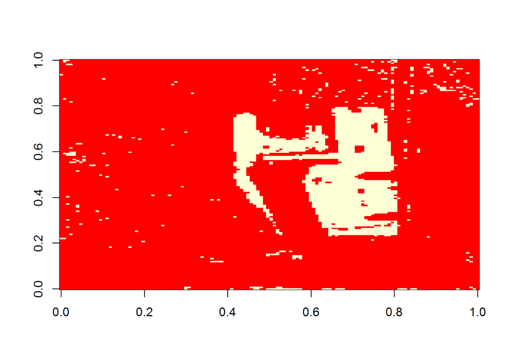

```r
accuracy_image <- quantization_errors > optimal_Threshold
image(accuracy_image)
```